# GCC_harjeet _singh_18125760026

# QUESTION 3

# IS THERE ANY DIFFERENCE BETWEEN TWO GENDERS IN THE PURPOSE OF TAKING CREDIT

#### Attribute 4: (qualitative) Purpose

- A40 : car (new)
- A41 : car (used)
- A42 : furniture/equipment
- A43 : radio/television
- A44 : domestic appliances
- A45 : repairs
- A46 : education
- A47 : vacation
- A48 : retraining
- A49 : business
- A410 : others

# MALE

```python
df[df['Peronal Status & Gender'].isin(['A91','A93','A94'])]['Purpose'].value_counts()
#df['Purpose'].value_counts()
```

```
A43     195
A40     164
A42     107
A41      79
A49      78
A46      29
A45      17
A410      9
A48       6
A44       6
Name: Purpose, dtype: int64
```

# FEMALE

```python
df[df['Peronal Status & Gender'].isin(['A92','A95'])]['Purpose'].value_counts()
```

```
A43     85
A42     74
A40     70
A41     24
A46     21
A49     19
A44      6
A45      5
A48      3
A410     3
Name: Purpose, dtype: int64
```

# QUESTION 4

# The relationship between job skill levels and amount of credit taken

#### Attribute 17: (qualitative) Job

- A171 : unemployed/ unskilled - non-resident
- A172 : unskilled - resident
- A173 : skilled employee / official
- A174 : management/ self-employed/highly qualified employee/ officer

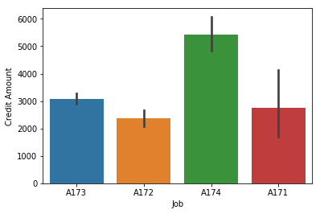

```python
import seaborn as sns
import warnings
warnings.filterwarnings('ignore')
import matplotlib.pyplot as plt
sns.barplot(x = 'Job', y = 'Credit Amount', data = df)
plt.show()
### from the below plot we can see that skilled employees(A173) and self employed employees(A174) have taken more credit
### amount when compared to the unskilled and unemployed
```

# predict the customer as good or bad by deploying different classification techniques

```python
df=pd.get_dummies(df)
df.head(1)
```

|  | Duration | Credit Amount | Installment rate in percentage of disposable income | Present Residence since (in yrs) | Age | Number of Existing Credits at this bank | Number of People being liable to provide maintance for | Target Variable | Existing Checking_A11 | Existing Checking_A12 | ... | Telephone_A192 | Foreign Worker_A201 | Foreign Worker_A202 | AgeCI_19 - 27 | AgeCI_28 - 36 | AgeCI_37 - 45 | AgeCI_46 - 54 | AgeCI_55 - 63 | AgeCI_64 - 72 | AgeCI_73 - 81 |
| --- | --- | --- | --- | --- | --- | --- | --- | --- | --- | --- | --- | --- | --- | --- | --- | --- | --- | --- | --- | --- | --- |
| 0 | 6 | 1169 | 4 | 4 | 67 | 2 | 1 | 1 | 1 | 0 | ... | 1 | 1 | 0 | 0 | 0 | 0 | 0 | 0 | 1 | 0 |

1 rows × 69 columns

```python
from sklearn.model_selection import train_test_split
train, test=train_test_split(df,test_size=0.7,random_state=100)
```

```python
train_x = train.drop('Target Variable',axis=1)
train_y = train['Target Variable']

test_x = test.drop('Target Variable',axis=1)
test_y = test['Target Variable']
```

```python
from sklearn.tree import DecisionTreeClassifier
from sklearn.ensemble import RandomForestClassifier
from sklearn.neighbors import KNeighborsClassifier
from sklearn.ensemble import AdaBoostClassifier
from sklearn.metrics import accuracy_score, confusion_matrix
from sklearn.naive_bayes import GaussianNB
from sklearn.metrics import auc, roc_curve
import warnings
warnings.filterwarnings('ignore')
from sklearn.naive_bayes import MultinomialNB
from sklearn.model_selection import train_test_split
l=[]
model_1aa=DecisionTreeClassifier(max_depth=3)
model_2aa=RandomForestClassifier(random_state=100,n_estimators=500)
model_3aa=KNeighborsClassifier(n_neighbors=5)
model_4aa=AdaBoostClassifier(n_estimators=500, random_state=100,learning_rate=1)
model_5aa=GaussianNB()
model_6aa=MultinomialNB(alpha=2)
a=(model_1aa,model_2aa,model_3aa,model_4aa,model_5aa,model_6aa)
for i in a:
    i.fit(train_x,train_y)
    pred_test=i.predict(test_x)
    a=accuracy_score(test_y,pred_test)
    l.append(a*100)
df=(pd.DataFrame({'Accuracy':l},index=['Decision Tree','Random Forest','KNN','Ada Boost','Gaussian Naive Bayes','Multinomial Naive Bayes']).sort_values('Accuracy',ascending=False))
df
```

|  | Accuracy |
| --- | --- |
| Random Forest | 75.000000 |
| Decision Tree | 71.000000 |
| Ada Boost | 66.285714 |
| Gaussian Naive Bayes | 65.285714 |
| KNN | 63.428571 |
| Multinomial Naive Bayes | 62.428571 |